# Multiple-linear regression.

**Created by Robin Cunningham, UNC Chapel Hill**

**Modified by Jan Hannig, UNC Chapel Hill**

*HOMEWORK 8 - Predicting Baby-weight*  
A Multi-linear regression analysis. **Please compose all answers in this R-Markdown document**.  
1. A file containing data on 1236 live births can be found at ‘https://drive.google.com/open?id=0B2lwGKhIFjYYbDY3eWVubEZzX28’. We will use this dataset to construct a multi-linear model for predicting birthweight from other variables.  
a. Write and execute code to read the csv file ‘babies.csv’, assign it to the object ‘babies’ and summarize the variables.

```r
  babies = read.csv("babies.csv",header = TRUE)
  head(babies)
```

```
##   case bwt gestation parity age height weight smoke
## 1    1 120       284      0  27     62    100     0
## 2    2 113       282      0  33     64    135     0
## 3    3 128       279      0  28     64    115     1
## 4    4 123        NA      0  36     69    190     0
## 5    5 108       282      0  23     67    125     1
## 6    6 136       286      0  25     62     93     0
```

```r
  summary(babies)
```

```
##       case             bwt          gestation         parity
##  Min.   :   1.0   Min.   : 55.0   Min.   :148.0   Min.   :0.0000
##  1st Qu.: 309.8   1st Qu.:108.8   1st Qu.:272.0   1st Qu.:0.0000
##  Median : 618.5   Median :120.0   Median :280.0   Median :0.0000
##  Mean   : 618.5   Mean   :119.6   Mean   :279.3   Mean   :0.2549
##  3rd Qu.: 927.2   3rd Qu.:131.0   3rd Qu.:288.0   3rd Qu.:1.0000
##  Max.   :1236.0   Max.   :176.0   Max.   :353.0   Max.   :1.0000
##                                   NA's   :13
##       age            height          weight          smoke
##  Min.   :15.00   Min.   :53.00   Min.   : 87.0   Min.   :0.0000
##  1st Qu.:23.00   1st Qu.:62.00   1st Qu.:114.8   1st Qu.:0.0000
##  Median :26.00   Median :64.00   Median :125.0   Median :0.0000
##  Mean   :27.26   Mean   :64.05   Mean   :128.6   Mean   :0.3948
##  3rd Qu.:31.00   3rd Qu.:66.00   3rd Qu.:139.0   3rd Qu.:1.0000
##  Max.   :45.00   Max.   :72.00   Max.   :250.0   Max.   :1.0000
##  NA's   :2       NA's   :22      NA's   :36      NA's   :10
```

b. As you can see, there are 8 variables and a fair number of missing data points. Remove all cases with missing data and assign the resulting data frame to ‘bbycomp’.

```r
  bbycomp = na.omit(babies,)

  head(bbycomp)
```

```
##   case bwt gestation parity age height weight smoke
## 1    1 120       284      0  27     62    100     0
## 2    2 113       282      0  33     64    135     0
## 3    3 128       279      0  28     64    115     1
## 5    5 108       282      0  23     67    125     1
## 6    6 136       286      0  25     62     93     0
## 7    7 138       244      0  33     62    178     0
```

c. A **Dataset Codebook** is a guide to what each of the variables represents. Note that for the purpose of this study, we will consider each variable to be numerical. Complete the comment box below to create a codebook for these data. Include units if you can figure them out.

```
Variables:
i. Case - the number assigned to the mother
ii. bwt - Babies weight in Ounces
iii. gestation - This column represents the number of days it takes from conception to birth of each baby.
iv. parity - the number of preganancies a woman has that makes it to gestational age.pretty much has mother been preganant before.
v. age - Represents age of the mother in year.
vi. height - Height of the babies in centimeters
vii. weight - the weight of the mother in pounds.
viii. smoke - The smoke column represents whether or not the parent smokes. represented in binary, 1's being yes and 0's no.
```

d.Do some exploratory analysis by looking at histograms of the 7 variables and plots of bwt versus each of the six explanatory variables. In the comment box below, make a note of any concerns. *It will save some typing to assign the right variables to `Y, X1, ..., X6`, so I did that for you.*

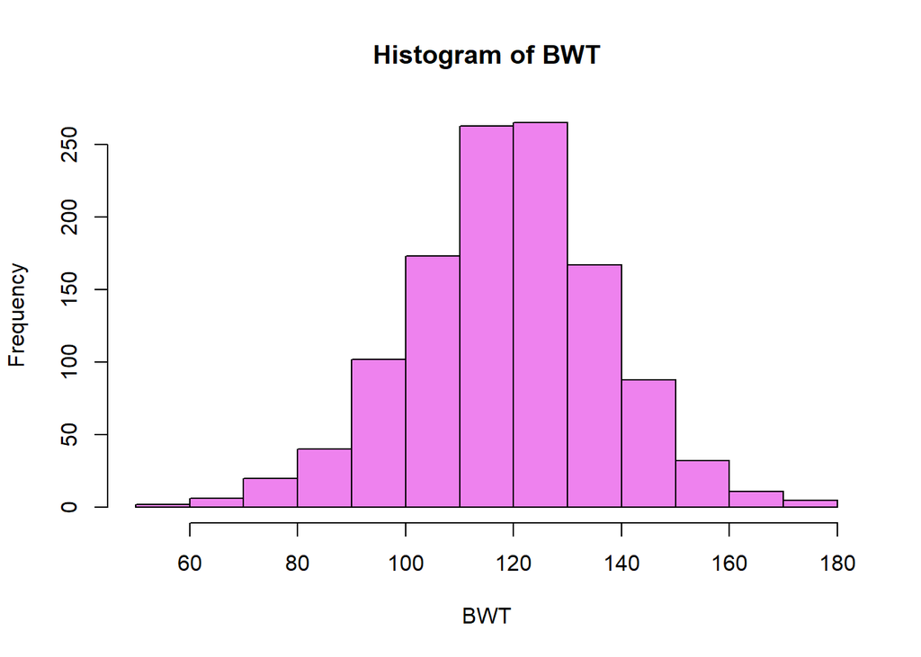

```r
#Assign Short variable names
Y  <- bbycomp$bwt
X1 <- bbycomp$gestation
X2 <- bbycomp$parity
X3 <- bbycomp$age
X4 <- bbycomp$height
X5 <- bbycomp$weight
X6 <- bbycomp$smoke

#Histograms
hist(Y,xlab="BWT",main= "Histogram of BWT", col = "violet")
```

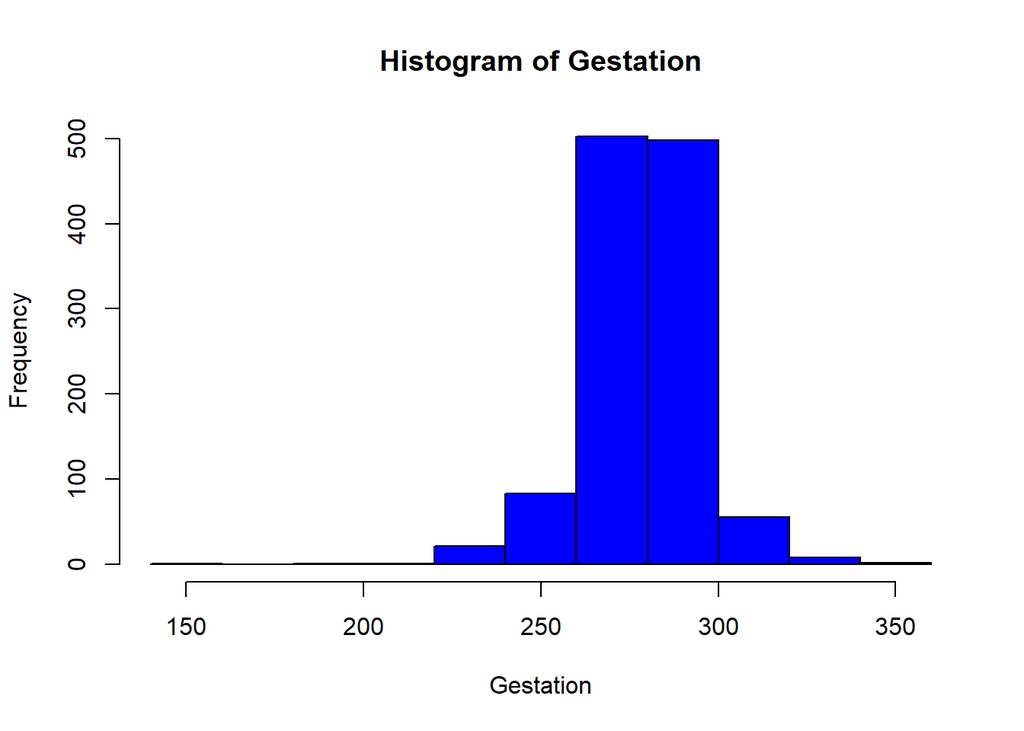

```r
hist(X1,xlab="Gestation",main= "Histogram of Gestation", col = "blue")
```

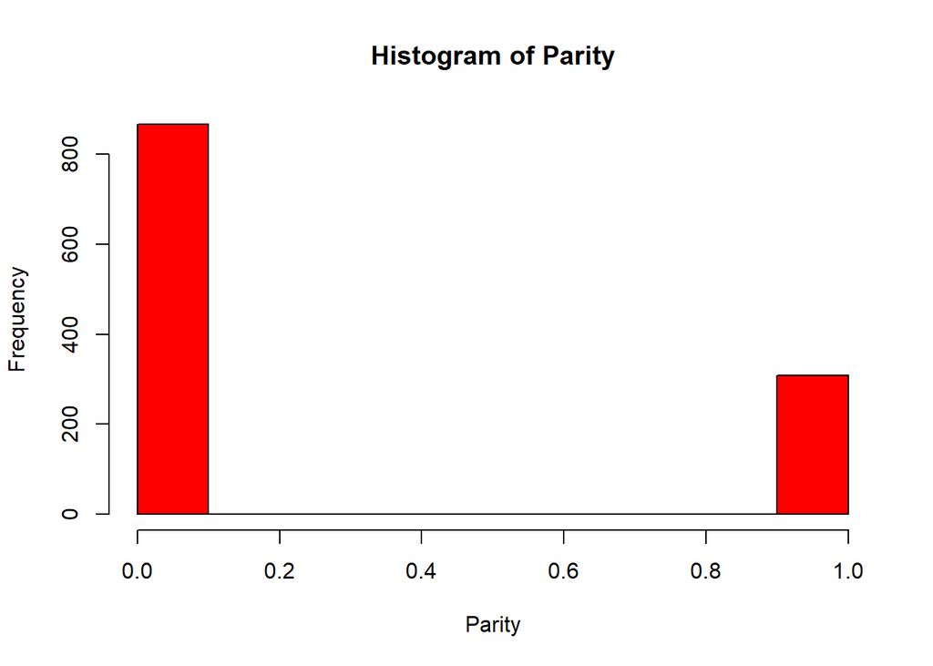

```r
hist(X2,xlab="Parity",main= "Histogram of Parity", col = "red")
```

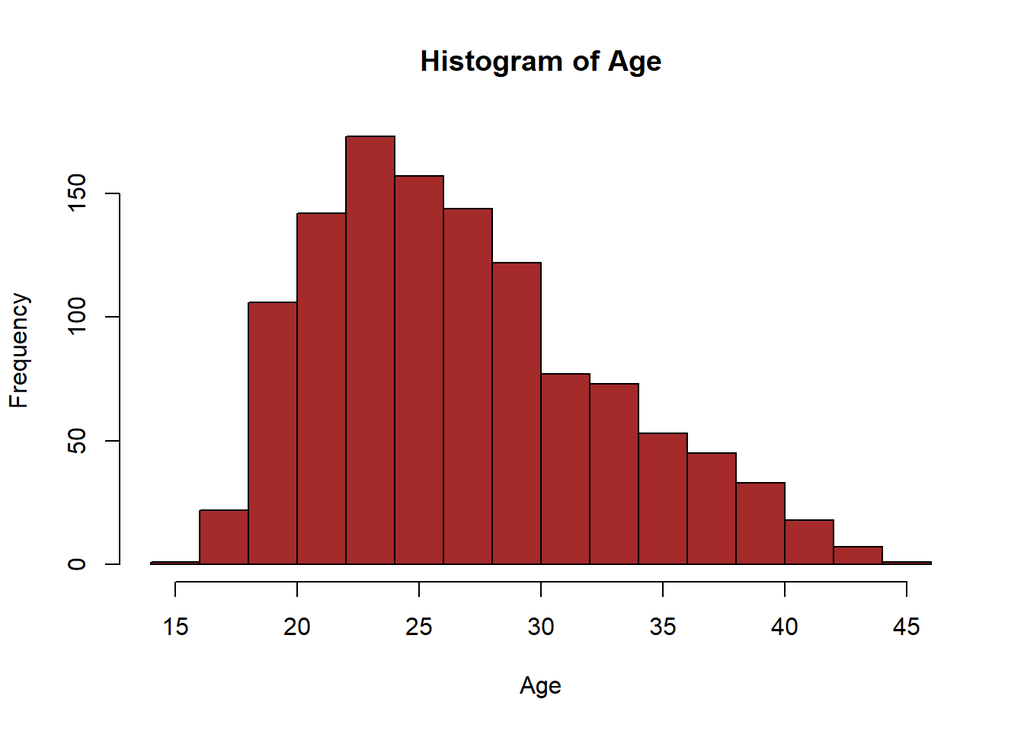

```r
hist(X3,xlab="Age",main= "Histogram of Age", col = "brown")
```

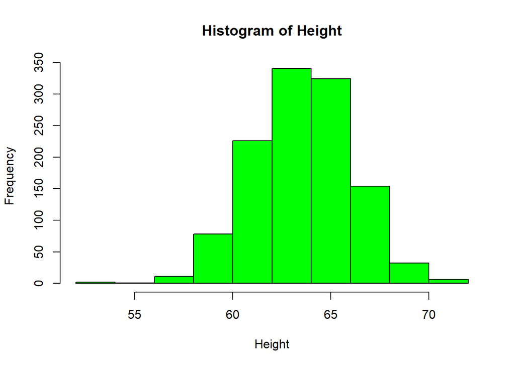

```r
hist(X4,xlab="Height",main= "Histogram of Height", col = "green")
```

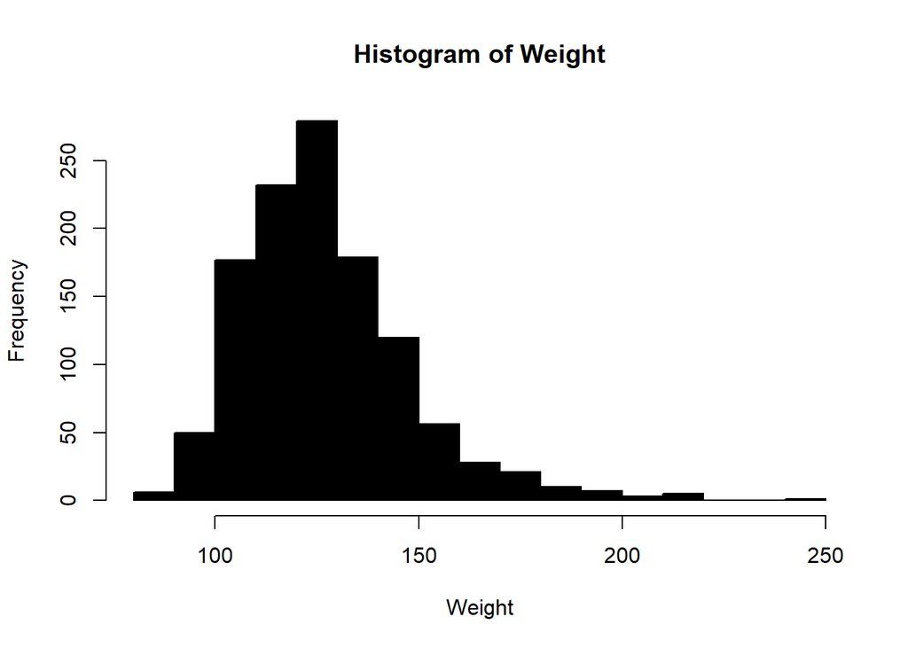

```r
hist(X5,xlab="Weight",main= "Histogram of Weight", col = "black")
```

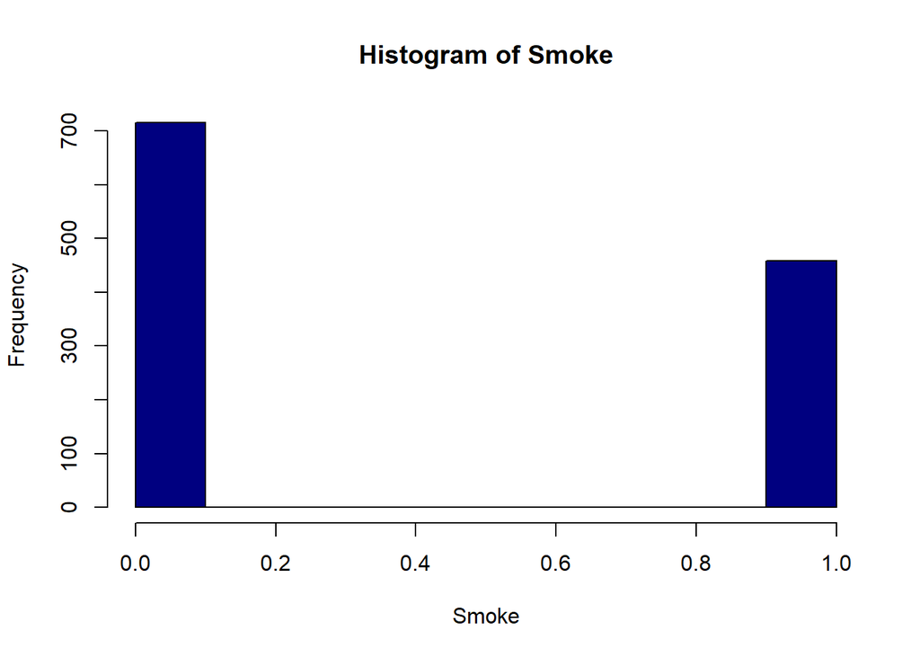

```r
hist(X6,xlab="Smoke",main= "Histogram of Smoke", col = "navy")
```

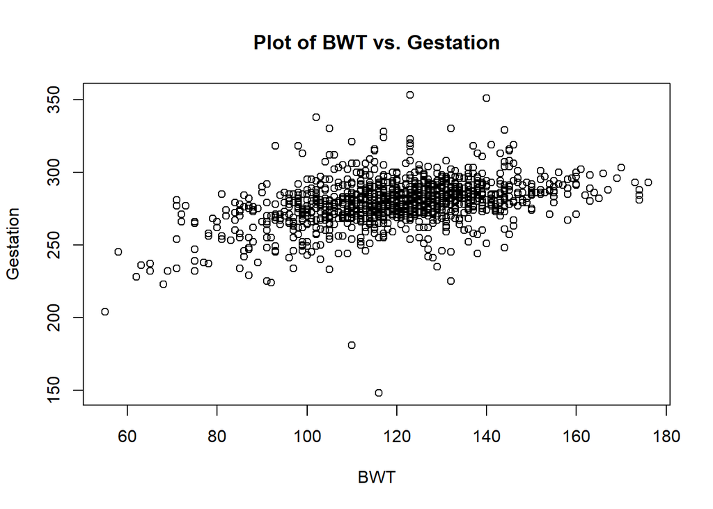

```r
#Plots of Y versus X_i

plot(Y, X1, xlab= "BWT", ylab="Gestation", main="Plot of BWT vs. Gestation")
```

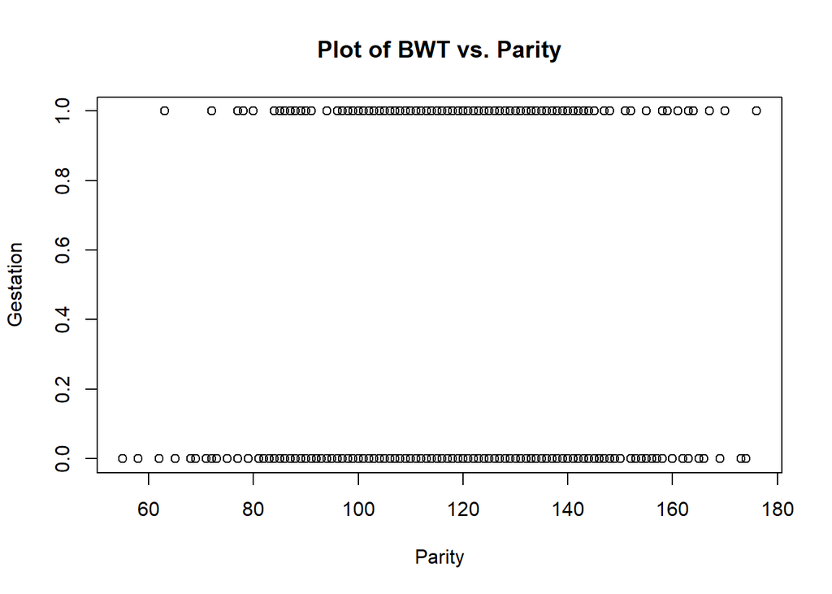

```r
plot(Y, X2, xlab= "Parity", ylab="Gestation", main="Plot of BWT vs. Parity")
```

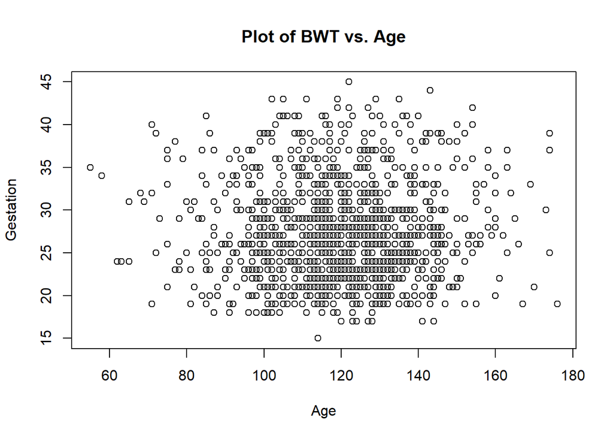

```r
plot(Y, X3, xlab= "Age", ylab="Gestation", main="Plot of BWT vs. Age")
```

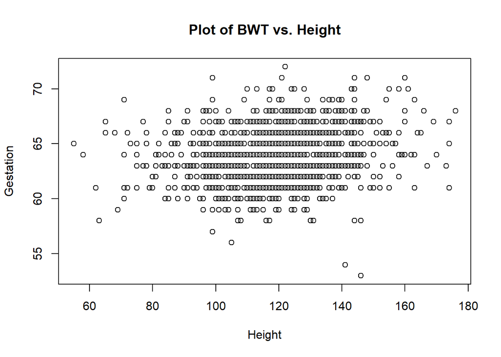

```r
plot(Y, X4, xlab= "Height", ylab="Gestation", main="Plot of BWT vs. Height")
```

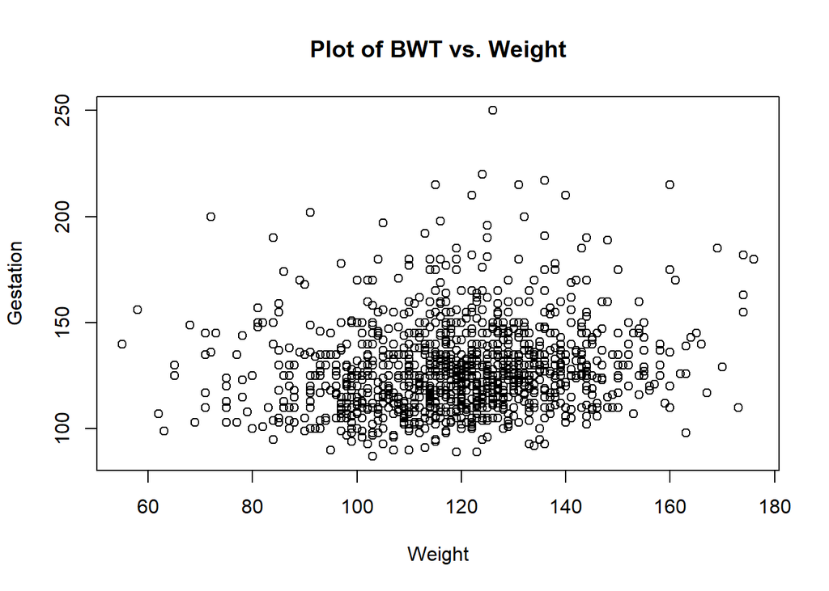

```r
plot(Y, X5, xlab= "Weight", ylab="Gestation", main="Plot of BWT vs. Weight")
```